# Zip code and CPD Analysis

Martin Gleason, MS

1/31/2020

## Summary of ask:

The following questions are guiding this GIS analysis:

- Which Chicago Police Department Districts and Cook County zip codes intersect?
- How many zip codes are in each particular CPD district?
- How does this zip code interaction impact case assignment by zip code?

## Method

The first step was to create a map of Cook County zip codes, complete with a boundary of the entire county, and then overlay it with the [CPD district shapefile.](https://data.cityofchicago.org/Public-Safety/CPD-districts/7hhi-ktqw) Setting up the district boundaries was easy, as this file is part of the [Chicago Data Portal](https://data.cityofchicago.org) and can be used with a variety of GIS products. Zip code integration was a bit more difficult.

The first issue seems to be a distinction without a difference: [Zipcodes are not polygons, but linear features.](http://www.georeference.org/doc/zip_codes_are_not_areas.htm) Zip codes represent postal routes, and may include neighborhoods, a single building, or a United States Naval vessel . While zip codes are frequently used in statistical models and maps, these zip codes are frequently derived from [Zipcode Tabulation Areas,](https://www.census.gov/programs-surveys/geography/guidance/geo-areas/zctas.html) which are maintained not by the USPS, but by the US Census Bureau. ZCATS are not 1:1 representation of Zip codes, and may vary as much as 20% with regard to areas covered. For cook county, this distinction may impact up to 3 zip codes, which in turn could impact the assignment of dozens, if not hundreds, of cases.

The second issue was more technical: How to get the zip code shape files. Pitney/Bowes sells a GIS solution for $399/year. Their product does not depend on the user knowing GIS data, and is regularly updated. The US Census Bureau offers TIGER/Line files as part of their open data project. TIGER/Line files are large, and require additional filtering to get to specific geographic locales. Cook County GIS does have a ZCTAS based layer in ArcGIS; however, at present my access to running analysis is limited. To generate this report, I pulled the ZCTAS file from the US Census Bureau and used the `sf` package to create and analyze geographic data.

The interactive map below is the sum of this work. Hovering over a Zip code creates a pop up message of the zip code, where as markers are CPD district names and headquarters. Lastly, CPD districts are also mapped to a specific color.

### Leaflet Map of Cook County Zip codes and Chicago Police Districts

[interactive chart not shown]

### Intersection Table

This table calculates the number of zip codes that intersect with a district. This means if a line of a zip codes intersects with the border of a CPD district – including overlapping borders – it is counted as an intersection. A tabular view provides additional insight into the difficulty of assignment by zip code: Any zip code solution will require a Zip code and district dividing line. A family whose home is “on the line” between a zip codes and districts will needs additional logic to solve.

Count of Intersections Between City of Chicago Police Districts and Zip codes

| CPD District Number | Number of Zipcode Intersections |
| --- | --- |
| 1 | 11 |
| 2 | 6 |
| 3 | 6 |
| 4 | 6 |
| 5 | 8 |
| 6 | 6 |
| 7 | 4 |
| 8 | 15 |
| 9 | 7 |
| 10 | 6 |
| 11 | 8 |
| 12 | 13 |
| 14 | 6 |
| 15 | 5 |
| 16 | 17 |
| 17 | 7 |
| 18 | 8 |
| 19 | 7 |
| 20 | 5 |
| 22 | 9 |
| 24 | 8 |
| 25 | 9 |

### Intersection Plot

This visualization breakdown the number of intersections of zip codes in a particular district.

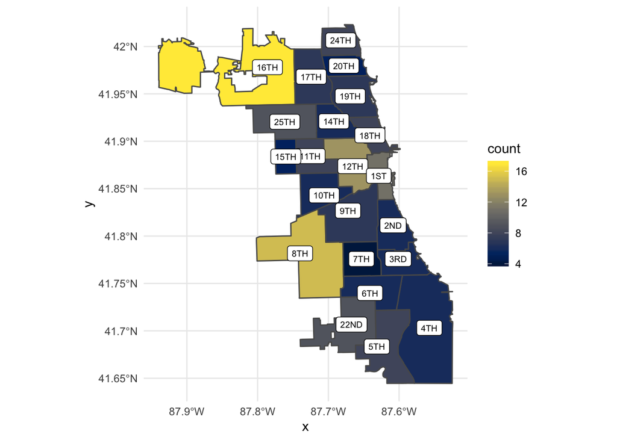

How this dividing line is maintained in future versions of our instance of Supervisor also needs to be considered: Zip codes and districts will change. Moving the district, zip code, or dividing line becomes more cumbersome and complicated because it is set manual by the developers. A full [GIS Point in Polygon](http://wiki.gis.com/wiki/index.php/Point_in_polygon) solution, either by MS SQL Server, ArcGIS or Google Maps API provides a more modular solution that will be easier to maintain and alter during the lifetime of the cFive contract.